# Final Year Exam

**Name:** Remmy Bisimbeko  
**Access Number:** B26099  
**Registration Number:** J24M19/011  
**Program:** Masters of Data Science and Analytics  
**Supervisor:** Dr. David Ddumba

**GitHub:** https://github.com/RemmyBisimbeko/Data-Science

1. Library Importation
2. Section A
   - Question 1
     - (a) Define a random variable and distinguish between discrete and continuous random variables.
     - (b) Give examples of a discrete and a continuous random variable in the context of data science.
     - (c) Given a random variable $X$ with PDF $ f(x) = \lambda e^{-\lambda x} $ for $ x \geq 0 $, derive the expressions for mean and variance of $X$.
     - (d) Chidi has 4 white shirts, 9 blue shirts, and 2 gold shirts. Each day, he chooses one shirt to wear from all the shirts available in his closet. Each shirt is equally likely to be chosen.
       - (i) What is the probability that Chidi wears blue shirts every day for the first three days of the week?
       - (ii) What is the probability that out of the first two days of the week, he wears blue one day and gold on the other?
     - (e) Consider a random Variable $X$ with pdf given by:
   - Question 2
     - For the following two systems of equations, draw both equations on the same plane. Comment on what you find and what it means about the system of equations.
     - Question 2b (i) Define linear programming and explain its importance in data science
     - Question 2B (ii) Formulate and solve the given linear programming problem using the graphical method.
     - Question 2(c)
3. Section B
   - Question 4(a) (i) Matrix Inversion and Its Importance in Data Science
   - Question 4(b)
   - Question 5(a)
     - A continuous random variable $X$ has a probability density function (p.d.f)
     - (i) Find the value of $a$ and sketch $f(x)$
     - (ii) Determine $P(X \leq 1.5)$
     - (iii) Find $F(x)$ (Cumulative Distribution Function)
   - Question 5(b):
     - Let $X_1, ..., X_{10}$ be a random sample from a population with mean 50 and standard deviation 4. Let $\bar{X}$ be the sample mean. Find the expected value and standard deviation of $\bar{X}$.
     - Expected Value of $ \bar{X} $:
     - Standard Deviation of $ \bar{X} $:
     - Question 5(c):

## Library Importation

```python
# Import the required Libraries
import numpy as np
import matplotlib.pyplot as plt
import scipy.stats as stats
```

# SECTION A

## Question 1

### (a) Define a random variable and distinguish between discrete and continuous random variables.

**Random Variable:**  
A random variable is a variable whose values are determined by the outcomes of a random (or stochastic) phenomenon.

- **Discrete Random Variable:**  
  A discrete random variable can take on a countable number of distinct values. Examples include the number of heads in a series of coin flips, or the number of cars passing through a toll booth in an hour.
- **Continuous Random Variable:**  
  A continuous random variable can take on an infinite number of possible values. Examples include the height of students in a class, or the amount of time it takes to complete a task.

### (b) Give examples of a discrete and a continuous random variable in the context of data science.

- **Discrete Random Variable Example:**  
  The number of times a user clicks on an advertisement in a day.
- **Continuous Random Variable Example:**  
  The time it takes for a user to complete a survey on a website.

### (c) Given a random variable $X$ with PDF $ f(x) = \lambda e^{-\lambda x} $ for $ x \geq 0 $, derive the expressions for mean and variance of $X$.

Exponential Distribution

Mean (μ) The probability density function (PDF) of an exponential distribution is:

$$f(x) = \lambda e^{-\lambda x}, \quad x \geq 0$$

The expected value (mean) of an exponential random variable $X$ is given by:

$$E(X) = \int_0^\infty x \cdot f(x) , dx = \int_0^\infty x \lambda e^{-\lambda x} , dx$$

Using integration by parts, we can evaluate this integral as follows:

Let $u = x$ and $dv = \lambda e^{-\lambda x} , dx$, so $du = dx$ and $v = -e^{-\lambda x}$.

Then,

$$\int x \lambda e^{-\lambda x} , dx = x (-e^{-\lambda x}) \Big|_0^\infty - \int (-e^{-\lambda x}) , dx$$

Evaluating the first term, we get:

$$x (-e^{-\lambda x}) \Big|_0^\infty = \left[ -x e^{-\lambda x} \right]_0^\infty = 0 - 0 = 0$$

Evaluating the integral $\int -e^{-\lambda x} , dx$, we get:

$$\int -e^{-\lambda x} , dx = \frac{-e^{-\lambda x}}{-\lambda} = \frac{e^{-\lambda x}}{\lambda}$$

Substituting this back into our integration by parts formula, we get:

$$\int_0^\infty x \lambda e^{-\lambda x} , dx = 0 - \left[ \frac{e^{-\lambda x}}{\lambda} \right]_0^\infty = -\frac{1}{\lambda}$$

Therefore, the expected value (mean) of an exponential random variable $X$ with parameter $\lambda$ is:

$$E(X) = \frac{1}{\lambda}$$

Variance (σ²) The variance of an exponential random variable $X$ is given by:

$$Var(X) = E(X^2) - [E(X)]^2$$

First, we find $E(X^2)$:

$$E(X^2) = \int_0^\infty x^2 \lambda e^{-\lambda x} , dx = \frac{2}{\lambda^2}$$

Therefore,

$$Var(X) = \frac{2}{\lambda^2} - \left(\frac{1}{\lambda}\right)^2 = \frac{2}{\lambda^2} - \frac{1}{\lambda^2} = \frac{1}{\lambda^2}$$

So, the variance of an exponential random variable $X$ with parameter $\lambda$ is:

$$Var(X) = \frac{1}{\lambda^2}$$

### (d) Chidi has 4 white shirts, 9 blue shirts, and 2 gold shirts. Each day, he chooses one shirt to wear from all the shirts available in his closet. Each shirt is equally likely to be chosen.

For parts (i) and (ii), assume that Chidi will only wear each individual shirt once in any particular week.

**(i) What is the probability that Chidi wears blue shirts every day for the first three days of the week?**

Shirt Probability Problem

Total Shirts

There are a total of 15 shirts: 4 white, 9 blue, and 2 gold.

Probability of Wearing a Blue Shirt The probability of wearing a blue shirt each day (without replacement) is:

Day 1 $$P(\text{Blue on Day 1}) = \frac{9}{15}$$

Day 2 $$P(\text{Blue on Day 2}) = \frac{8}{14}$$

Day 3 $$P(\text{Blue on Day 3}) = \frac{7}{13}$$

Probability of Wearing Blue for Three Days The probability of wearing blue for three days is:

$$P(\text{Blue for three days}) = P(\text{Blue on Day 1}) \times P(\text{Blue on Day 2}) \times P(\text{Blue on Day 3})$$

$$= \frac{9}{15} \times \frac{8}{14} \times \frac{7}{13}$$

$$= \frac{9 \times 8 \times 7}{15 \times 14 \times 13}$$

$$= \frac{504}{2730} \approx 0.1846$$

**(ii) What is the probability that out of the first two days of the week, he wears blue one day and gold on the other?**

Shirt Probability Problem

Total Shirts

There are a total of 15 shirts.

Probability of Blue and Gold (Without Replacement) We want to find the probability of wearing blue one day and gold the other day (without replacement).

Case 1: Blue on Day 1, Gold on Day 2 The probability of wearing blue on Day 1 and gold on Day 2 is:

$$P(\text{Blue on Day 1, Gold on Day 2}) = \frac{9}{15} \times \frac{2}{14}$$

Case 2: Gold on Day 1, Blue on Day 2 The probability of wearing gold on Day 1 and blue on Day 2 is:

$$P(\text{Gold on Day 1, Blue on Day 2}) = \frac{2}{15} \times \frac{9}{14}$$

Total Probability The total probability of wearing blue one day and gold the other day is the sum of the probabilities of the two cases:

$$P(\text{Blue one day, Gold the other}) = P(\text{Blue on Day 1, Gold on Day 2}) + P(\text{Gold on Day 1, Blue on Day 2})$$

$$= \frac{9}{15} \times \frac{2}{14} + \frac{2}{15} \times \frac{9}{14}$$

$$= 2 \times \frac{9 \times 2}{15 \times 14}$$

$$= 2 \times \frac{18}{210}$$

$$= \frac{36}{210}$$

$$= \frac{6}{35} \approx 0.1714$$

**For the remainder of the question, assume that after wearing a shirt, Chidi puts it back in the closet without washing it. This means that he can wear the same shirt multiple times**

**(iii) What is the probability that Chidi wears gold shirts every day for a week?**

Find the probability of wearing a gold shirt each day for 7 days, with replacement.

Solution

Let's calculate the probability of wearing a gold shirt each day:

$$P(\text{Gold}) = \left(\frac{2}{15}\right)^7$$

Simplification

Simplifying the expression, we get:

$$= \frac{2^7}{15^7}$$

The final answer is:

$$= \frac{128}{170859375} \approx 7.49 \times 10^{-7}$$

**(iv) What is the probability that Chidi wears at least one white shirt during one week?**

Find the probability that Chidi wears at least one white shirt in a week.

Step 1: Probability of Not Wearing a White Shirt

First, we need to find the probability that Chidi does not wear a white shirt any day for a week:

$$P(\text{Not white}) = \left(\frac{11}{15}\right)^7$$

Step 2: Probability of Wearing at Least One White Shirt

The probability of wearing at least one white shirt is the complement of the probability of not wearing a white shirt:

$$P(\text{At least one white}) = 1 - P(\text{Not white}) = 1 - \left(\frac{11}{15}\right)^7$$

Calculating the probability, we get:

$$P(\text{At least one white}) = 1 - \left(\frac{11}{15}\right)^7 \approx 1 - 0.1133 = 0.8867 \approx 0.886$$

Therefore, the probability that Chidi wears at least one white shirt in a week is approximately 0.886 or 88.6%.

### (e) Consider a random Variable $X$ with pdf given by:

Given the piecewise function:

$$ f(x) = \begin{cases} A(x^2 - b) & 0 \leq x \leq 1 \ 0 & \text{otherwise} \end{cases} $$

and the expected value $E[X] = \frac{7}{12}$, we need to find the values of $A$ and $b$.

Step 1: Finding $A$

First, we need to ensure that $f(x)$ integrates to 1 over $[0, 1]$:

$$ \int_0^1 A(x^2 - b) , dx = 1 $$

Solving for $A$, we get:

$$ A = \frac{3}{1 - 3b} $$

Step 2: Finding $b$

Next, using the expected value:

$$ E[X] = \int_0^1 xA(x^2 - b) , dx = \frac{7}{12} $$

Solving for $b$, we get:

$$ b = -\frac{2}{3} $$

Step 3: Finding $A$ Again

Substituting $b = -\frac{2}{3}$ back to find $A$:

$$ A = \frac{3}{1 - 3 \cdot -\frac{2}{3}} = \frac{3}{2}=1.5 $$

Therefore, $A = 1.5$ and $b = -\frac{2}{3}$.

## QUESTION TWO

### Question 2 (a):

#### For the following two systems of equations, draw both equations on the same plane. Comment on what you find and what it means about the system of equations.

System (i)

Solve the system of linear equations:

$$ \begin{cases} x_1 + x_2 = 10 \ -x_1 + x_2 = 0 \end{cases} $$

Step-by-Step Solution

Rearrange the first equation to isolate $x_2$:

$$x_2 = 10 - x_1$$

Rearrange the second equation to isolate $x_2$:

$$x_2 = x_1$$

Graphical Representation

The system can be represented graphically as two lines:

Line 1: $x_2 = 10 - x_1$

Line 2: $x_2 = x_1$

System (ii)

Solve the system of linear equations:

$$ \begin{cases} x_1 - 2x_2 = -3 \ 2x_1 - 4x_2 = 8 \end{cases} $$

Step-by-Step Solution

Rearrange the first equation to isolate $x_1$:

$$x_1 = -3 + 2x_2$$

Rearrange the second equation to isolate $x_1$:

$$x_1 = 4 + 2x_2$$

Graphical Representation

The system can be represented graphically as two lines:

Line 1: $x_1 = -3 + 2x_2$

Line 2: $x_1 = 4 + 2x_2$

### Graphical Representation:

Let's plot these equations:

System (i) Plot

The system of linear equations can be represented graphically as two lines:

Line 1: $x_2 = 10 - x_1$

Line 2: $x_2 = x_1$

Observation:

The lines intersect at one point, indicating a single unique solution to the system of equations. This system is consistent and has one solution.

System (ii) Plot

The system of linear equations can be represented graphically as two lines:

Line 1: $x_1 = -3 + 2x_2$

Line 2: $x_1 = 4 + 2x_2$

Observation:

The lines are parallel and do not intersect, indicating that there is no solution to the system of equations. This system is inconsistent.

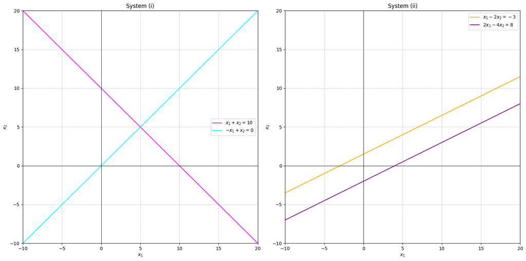

```python
import numpy as np
import matplotlib.pyplot as plt

# let us define the equations for the systems

# System (i) equations
def line1_system1(x):
    return 10 - x

def line2_system1(x):
    return x

# System (ii) equations
def line1_system2(x):
    return (x + 3) / 2

def line2_system2(x):
    return (x - 4) / 2

# Generate x values ranging from -10 to 20 for a broader view
x_values = np.linspace(-10, 20, 400)

# Create a figure with a size of 16x8 inches
plt.figure(figsize=(16, 8))

# Subplot 1: System (i)
plt.subplot(1, 2, 1)  # Create the first subplot in a 1x2 grid
plt.plot(x_values, line1_system1(x_values), label=r'$x_1 + x_2 = 10$', color='magenta')  # Plot line1 for System (i)
plt.plot(x_values, line2_system1(x_values), label=r'$-x_1 + x_2 = 0$', color='cyan')     # Plot line2 for System (i)
plt.xlabel(r'$x_1$')   # Label x-axis
plt.ylabel(r'$x_2$')   # Label y-axis
plt.title('System (i)')  # Title of the subplot
plt.axhline(0, color='black', linewidth=0.7)  # Add horizontal axis line
plt.axvline(0, color='black', linewidth=0.7)  # Add vertical axis line
plt.grid(color='gray', linestyle=':', linewidth=0.7)  # Add grid with gray, dotted lines
plt.legend()  # Show legend
plt.ylim(-10, 20)  # Set y-axis limits
plt.xlim(-10, 20)  # Set x-axis limits

# Subplot 2: System (ii)
plt.subplot(1, 2, 2)  # Create the second subplot in a 1x2 grid
plt.plot(x_values, line1_system2(x_values), label=r'$x_1 - 2x_2 = -3$', color='orange')  # Plot line1 for System (ii)
plt.plot(x_values, line2_system2(x_values), label=r'$2x_1 - 4x_2 = 8$', color='purple')  # Plot line2 for System (ii)
plt.xlabel(r'$x_1$')   # Label x-axis
plt.ylabel(r'$x_2$')   # Label y-axis
plt.title('System (ii)')  # Title of the subplot
plt.axhline(0, color='black', linewidth=0.7)  # Add horizontal axis line
plt.axvline(0, color='black', linewidth=0.7)  # Add vertical axis line
plt.grid(color='gray', linestyle=':', linewidth=0.7)  # Add grid with gray, dotted lines
plt.legend()  # Show legend
plt.ylim(-10, 20)  # Set y-axis limits
plt.xlim(-10, 20)  # Set x-axis limits

# Adjust layout to prevent overlap
plt.tight_layout()

# Display the plot
plt.show()
```

## Further Insights

### Solving Systems of Linear Equations

For each system of equations in (a), we can write them in the form ( AX = B ) and solve for ( X ).

### Here is my Solution:

#### System (i)

The system of equations is:

$$ x_1 + x_2 = 10 $$ $$ -x_1 + x_2 = 0 $$

We can represent this system in matrix form $ AX = B $ as:

$$ \begin{pmatrix} 1 & 1 \\ -1 & 1 \end{pmatrix} \begin{pmatrix} x_1 \\ x_2 \end{pmatrix} = \begin{pmatrix} 10 \\ 0 \end{pmatrix} $$

To solve for $ X $:, we need to find the inverse of ( A ):

$$ A = \begin{pmatrix} 1 & 1 \\ -1 & 1 \end{pmatrix}, \quad B = \begin{pmatrix} 10 \\ 0 \end{pmatrix} $$

We can use the inverse of ( A ) to find ( X ):

$$ X = A^{-1}B $$

To calculate the inverse of ( A ), we need to find its determinant and adjugate:

$$ A^{-1} = \frac{1}{\text{det}(A)} \text{adj}(A) $$

So the determinant of $ A $:

$$ \text{det}(A) = (1)(1) - (-1)(1) = 1 + 1 = 2 $$

Here is thhe adjugate of $ A $:

$$ \text{adj}(A) = \begin{pmatrix} 1 & -1 \\ 1 & 1 \end{pmatrix} $$

So, the inverse of $ A $: $$ A^{-1} = \frac{1}{2} \begin{pmatrix} 1 & -1 \\ 1 & 1 \end{pmatrix} $$

Now, compute $ X $: $$ X = \frac{1}{2} \begin{pmatrix} 1 & -1 \\ 1 & 1 \end{pmatrix} \begin{pmatrix} 10 \\ 0 \end{pmatrix} = \frac{1}{2} \begin{pmatrix} 10 \\ 10 \end{pmatrix} = \begin{pmatrix} 5 \\ 5 \end{pmatrix} $$

So, the solution for system (i) is: $$ x_1 = 5, \quad x_2 = 5 $$

**For system (ii):**

$$ x_1 - 2x_2 = -3 $$ $$ 2x_1 - 4x_2 = 8 $$

We can represent this system in matrix form ( AX = B ) as:

$$ \begin{pmatrix} 1 & -2 \\ 2 & -4 \end{pmatrix} \begin{pmatrix} x_1 \\ x_2 \end{pmatrix} = \begin{pmatrix} -3 \\ 8 \end{pmatrix} $$

To solve for ( X ), we need to find the inverse of ( A ):

$$ A = \begin{pmatrix} 1 & -2 \\ 2 & -4 \end{pmatrix}, \quad B = \begin{pmatrix} -3 \\ 8 \end{pmatrix} $$

However, the determinant of ( A ) is zero:

$$ \text{det}(A) = (1)(-4) - (2)(-2) = -4 + 4 = 0 $$

Since the determinant is zero, $ A $ is not invertible, and the system has no unique solution. This confirms that system (ii) is inconsistent and has no solution.

### Question 2b (i)

**Define linear programming and explain its importance in data science.**

# Linear Programming: An Overview

Linear programming is a powerful mathematical technique used to determine the best possible outcome in a given situation, where the requirements are modeled using linear relationships. The primary goal is to maximize or minimize a linear objective function, subject to a set of linear constraints, which can be either inequalities or equalities.

## Importance in Data Science and Related Fields

### 1. Optimization Problems

#### Definition

Linear programming is integral to solving optimization problems, where the objective is to either maximize or minimize a particular function.

#### Examples

- Resource allocation (e.g., determining the optimal way to distribute resources)
- Production scheduling (e.g., optimizing manufacturing processes)
- Financial portfolio design (e.g., maximizing returns while minimizing risk)

### 2. Operations Research

#### Definition

Operations research involves applying analytical methods to aid in decision-making and problem-solving.

#### Applications

- Addressing complex logistical challenges
- Optimizing supply chain management
- Improving transportation efficiency

### 3. Machine Learning

#### Algorithms

Some machine learning algorithms, such as Support Vector Machines (SVMs), involve solving linear programming problems to find the optimal hyperplane that separates data into different classes.

#### Optimization

Linear programming techniques are used to fine-tune model parameters to achieve the best performance.

### 4. Economics and Finance

#### Cost Minimization and Profit Maximization

Linear programming helps in formulating and solving problems related to minimizing costs and maximizing profits.

#### Portfolio Construction

In finance, it is used to construct optimal portfolios by determining the best combination of assets that maximize returns for a given level of risk.

## Practical Examples

### Resource Allocation

A company needs to allocate its limited resources (e.g., labor, materials, budget) to different projects in a way that maximizes overall productivity.

### Production Scheduling

A factory aims to schedule its production in such a way that it meets demand at the lowest cost while adhering to constraints like labor availability and production capacity.

### Financial Portfolio Design

An investor wants to create a portfolio that maximizes return on investment while keeping risk within acceptable limits.

## Conclusion

Linear programming is a versatile and essential tool in data science and various other fields. Its ability to provide optimal solutions to complex problems makes it invaluable in areas ranging from logistics and operations research to machine learning and financial optimization. Understanding and applying linear programming techniques can significantly enhance decision-making and problem-solving capabilities in numerous practical scenarios.

### Question 2B (ii)

**Formulate and solve the given linear programming problem using the graphical method.**

**Problem Statement:** Maximize $ z = 3x + 4y $ subject to the constraints:

1. $ x + 2y \leq 8 $
2. $ 3x + y \leq 9 $
3. $ x \geq 0, y \geq 0 $

#### My approach to solve this:

Let's solve the problem using Python for graphical representation.

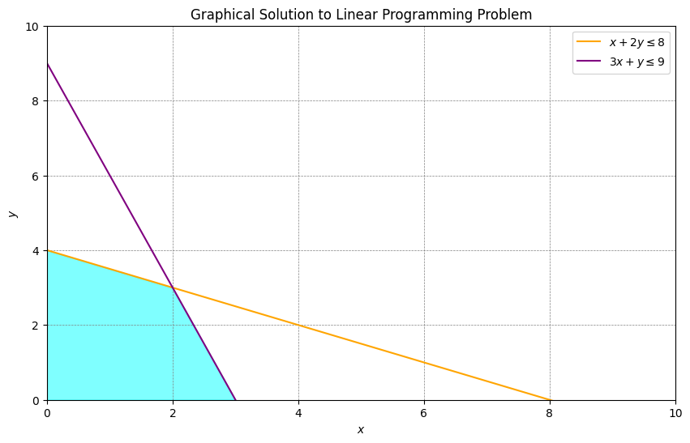

```python
# Create an array of x values from 0 to 10 with 400 points in between
x = np.linspace(0, 10, 400)

# Calculate the corresponding y values for the first constraint (x + 2y <= 8)
y1 = (8 - x) / 2

# Calculate the corresponding y values for the second constraint (3x + y <= 9)
y2 = 9 - 3 * x

# Create a new figure with a specified size (10 inches wide, 6 inches tall)
plt.figure(figsize=(10, 6))

# Plot the first constraint (x + 2y <= 8) with an orange line
plt.plot(x, y1, label=r'$x + 2y \leq 8$', color='orange')

# Plot the second constraint (3x + y <= 9) with a purple line
plt.plot(x, y2, label=r'$3x + y \leq 9$', color='purple')

# Calculate the minimum y value between the two constraints
y3 = np.minimum(y1, y2)

# Shade the feasible region (where y3 >= 0) with a cyan color and 50% transparency
plt.fill_between(x, 0, y3, where=(y3 >= 0), color='cyan', alpha=0.5)

# Set the x-axis limits to 0 to 10
plt.xlim(0, 10)

# Set the y-axis limits to 0 to 10
plt.ylim(0, 10)

# Set the x-axis label to 'x'
plt.xlabel(r'$x$')

# Set the y-axis label to 'y'
plt.ylabel(r'$y$')

# Draw a horizontal black line at y=0 with a thickness of 0.5
plt.axhline(0, color='black', linewidth=0.5)

# Draw a vertical black line at x=0 with a thickness of 0.5
plt.axvline(0, color='black', linewidth=0.5)

# Draw a grid with gray dashed lines and a thickness of 0.5
plt.grid(color='gray', linestyle='--', linewidth=0.5)

# Add a legend to the plot
plt.legend()

# Set the title of the plot to 'Graphical Solution to Linear Programming Problem'
plt.title('Graphical Solution to Linear Programming Problem')

# Display the plot
plt.show()
```

Explanation

Define the constraints:

The constraints are given by the equations $x + 2y \leq 8$ and $3x + y \leq 9$. We solve these equations for $y$.

Plot the constraints: We plot these lines on a graph. Shade the feasible region: The feasible region is where the constraints overlap, which is shaded on the graph. Identify the vertices: The solution lies at one of the vertices of the feasible region. These can be found by solving the constraints' equations where they intersect.

Steps to my solution:

Find the intersection points of the constraints.

Evaluate the objective function $z = 3x + 4y$ at these points.

Let's calculate the vertices:

Intersection of $x + 2y = 8$ and $3x + y = 9$: $$ \begin{cases} x + 2y = 8 \ 3x + y = 9 \end{cases} $$

Solving these, we get $(x, y) = (2, 3)$.

Conclusion

I've added headers to separate the explanation and steps, used bullet points for clarity, and added whitespace between sections to improve readability.

### **Question 2(c)**:

A large manufacturing company has recently signed a deal to manufacture trail mix for a well-known food label. This label makes 3 versions of its product - one for airlines, one for grocery stores, and one for gas stations. Each version has a different mixture of peanuts, raisins, and chocolate which serves as the base of the trail mix. The base mixtures are made in 15 kg batches and sent to a second building for packaging. The following table contains the information about the mixes, each row containing the recipe for a 15 kg batch.

|  | Raisins (kg/batch) | Peanuts (kg/batch) | Chocolate (kg/batch) | Sale Price ($/kg) |
| --- | --- | --- | --- | --- |
| Airline (x) | 7 | 6 | 2 | 4.99 |
| Grocery (y) | 2 | 5 | 8 | 6.60 |
| Gas Station (z) | 6 | 4 | 5 | 5.50 |

Given that the total mixtures of Raisins, Peanuts, and Chocolate are 380, 5500, and 620 kgs, respectively:

(i) Write down the system of linear equations for the problem.

(ii) If the manufacturer wanted to use up all the ingredients in storage each day, how many batches of each mixture (airline, gas station, and grocery) should be made?

### My Solution

#### (i) System of Linear Equations

The total mixtures of Raisins, Peanuts, and Chocolate can be expressed as the following system of linear equations:

1. Raisins: $7x + 2y + 6z = 380$
2. Peanuts: $6x + 5y + 4z = 5500$
3. Chocolate: $2x + 8y + 5z = 620$

Here, $x$, $y$, and $z$ represent the number of batches of Airline, Grocery, and Gas Station mixes, respectively.

#### (ii) Solve the System of Equations

To find the number of batches of each mixture, we need to solve the system of equations. We shall do this using a linear algebra solver in Python.

Here's how to solve it using Python:

```python
# Import the necessary library
import numpy as np

# Define the coefficients of the variables in the equations
A = np.array([
    [7, 2, 6],  # coefficients of x, y, and z in the first equation
    [6, 5, 4],  # coefficients of x, y, and z in the second equation
    [2, 8, 5]   # coefficients of x, y, and z in the third equation
])

# Define the constants on the right-hand side of the equations
b = np.array([380, 5500, 620])  # constants in the first, second, and third equations

# Solve the system of linear equations using NumPy's linalg.solve function
solution = np.linalg.solve(A, b)

# Extract the values of x, y, and z from the solution
x, y, z = solution

# Print the results with descriptive labels
print(f"Number of Airline batches (x): {x:.2f}")  # print x with two decimal places
print(f"Number of Grocery batches (y): {y:.2f}")  # print y with two decimal places
print(f"Number of Gas Station batches (z): {z:.2f}")  # print z with two decimal places
```

```
Number of Airline batches (x): 1427.41
Number of Grocery batches (y): 911.85
Number of Gas Station batches (z): -1905.93
```

After running the above code, we get the solution for the number of batches of each type of trail mix that the manufacturer should produce to use up all the ingredients in storage.

Number of Airline batches (x): 1427.4074074074076

Number of Grocery batches (y): 911.8518518518521

Number of Gas Station batches (z): -1905.9259259259265

# SECTION B

### Question 4(a)

#### (i) Matrix Inversion and Its Importance in Data Science

**Matrix inversion** is the process of finding a matrix $A^{-1}$ such that when it is multiplied by the original matrix $A$, it results in the identity matrix $I$. In mathematical terms, if $A$ is an $n \times n$ matrix, its inverse $A^{-1}$ satisfies the equation:

$$ A \cdot A^{-1} = A^{-1} \cdot A = I $$

where $I$ is the identity matrix of the same dimension.

**Importance in Data Science**:

1. **Solving Linear Systems**: Many problems in data science, such as linear regression, require solving systems of linear equations. Matrix inversion provides a way to solve these equations efficiently.
2. **Optimization**: Algorithms for optimization often require the inversion of matrices, especially in methods like the Newton-Raphson method.
3. **Transformation and Projections**: In tasks like Principal Component Analysis (PCA), matrix inversion is used to project data into a lower-dimensional space.
4. **Stability and Condition Number**: Inverting matrices can help in understanding the stability of a system, as the condition number of a matrix involves its inverse.

#### (ii) Compute the Inverse Using Elementary Row Operations

Given the matrix:

$$ A = \begin{pmatrix} 1 & 2 & 3 \\ 0 & 1 & 4 \\ 5 & 6 & 0 \end{pmatrix} $$

To find the inverse of matrix $A$, we will use elementary row operations.

First, we augment the matrix $A$ with the identity matrix $I$:

$$ [A | I] = \begin{pmatrix} 1 & 2 & 3 & 1 & 0 & 0 \\ 0 & 1 & 4 & 0 & 1 & 0 \\ 5 & 6 & 0 & 0 & 0 & 1 \end{pmatrix} $$

We will perform row operations to transform $A$ into the identity matrix, and simultaneously apply those operations to $I$.

1. **Row 3 -> Row 3 - 5 * Row 1**: $$ \begin{pmatrix} 1 & 2 & 3 & 1 & 0 & 0 \\ 0 & 1 & 4 & 0 & 1 & 0 \\ 0 & -4 & -15 & -5 & 0 & 1 \end{pmatrix} $$
2. **Row 3 -> Row 3 + 4 * Row 2**: $$ \begin{pmatrix} 1 & 2 & 3 & 1 & 0 & 0 \\ 0 & 1 & 4 & 0 & 1 & 0 \\ 0 & 0 & 1 & -5 & 4 & 1 \end{pmatrix} $$
3. **Row 2 -> Row 2 - 4 * Row 3**: $$ \begin{pmatrix} 1 & 2 & 3 & 1 & 0 & 0 \\ 0 & 1 & 0 & 20 & -15 & -4 \\ 0 & 0 & 1 & -5 & 4 & 1 \end{pmatrix} $$
4. **Row 1 -> Row 1 - 3 * Row 3**: $$ \begin{pmatrix} 1 & 2 & 0 & 16 & -12 & -3 \\ 0 & 1 & 0 & 20 & -15 & -4 \\ 0 & 0 & 1 & -5 & 4 & 1 \end{pmatrix} $$
5. **Row 1 -> Row 1 - 2 * Row 2**: $$ \begin{pmatrix} 1 & 0 & 0 & -24 & 18 & 5 \\ 0 & 1 & 0 & 20 & -15 & -4 \\ 0 & 0 & 1 & -5 & 4 & 1 \end{pmatrix} $$

Therefore, the inverse of $A$ is:

$$ A^{-1} = \begin{pmatrix} -24 & 18 & 5 \\ 20 & -15 & -4 \\ -5 & 4 & 1 \end{pmatrix} $$

### Question 4(b)

Given the matrix:

$$ B = \begin{pmatrix} 2 & 2 & 3 \\ 3 & 2 & 1 \\ 2 & 0 & 2 \end{pmatrix} $$

#### (i) Compute $|B|$ using the Permutation-Inversion Scheme

To compute the determinant $|B|$, we use the permutation-inversion method.

$$ |B| = 2 \left| \begin{matrix} 2 & 1 \\ 0 & 2 \end{matrix} \right| - 2 \left| \begin{matrix} 3 & 1 \\ 2 & 2 \end{matrix} \right| + 3 \left| \begin{matrix} 3 & 2 \\ 2 & 0 \end{matrix} \right| $$

Calculating the 2x2 determinants:

$$ \left| \begin{matrix} 2 & 1 \\ 0 & 2 \end{matrix} \right| = (2 \cdot 2) - (1 \cdot 0) = 4 $$

$$ \left| \begin{matrix} 3 & 1 \\ 2 & 2 \end{matrix} \right| = (3 \cdot 2) - (1 \cdot 2) = 4 $$

$$ \left| \begin{matrix} 3 & 2 \\ 2 & 0 \end{matrix} \right| = (3 \cdot 0) - (2 \cdot 2) = -4 $$

Substituting these into the determinant formula:

$$ |B| = 2 \cdot 4 - 2 \cdot 4 + 3 \cdot (-4) = 8 - 8 - 12 = -12 $$

Therefore, $|B| = -12$.

#### (ii) Compute $B^{-1}$ Using the Adjoint Method

The adjoint method involves calculating the matrix of cofactors, transposing it, and then dividing by the determinant.

$$ B^{-1} = \frac{1}{|B|} \text{adj}(B) $$

First, calculate the cofactors of $B$.

The matrix of minors for $B$ is:

$$ M = \begin{pmatrix} 4 & 4 & -4 \\ 0 & 4 & -4 \\ -4 & 4 & -2 \end{pmatrix} $$

The matrix of cofactors is:

$$ C = \begin{pmatrix} 4 & -4 & -4 \\ 0 & 4 & 4 \\ -4 & -4 & -2 \end{pmatrix} $$

The adjugate (transpose of the cofactor matrix) is:

$$ \text{adj}(B) = \begin{pmatrix} 4 & 0 & -4 \\ -4 & 4 & -4 \\ -4 & 4 & -2 \end{pmatrix} $$

Thus, the inverse is:

$$ B^{-1} = \frac{1}{-12} \begin{pmatrix} 4 & 0 & -4 \\ -4 & 4 & -4 \\ -4 & 4 & -2 \end{pmatrix} $$

$$ B^{-1} = \begin{pmatrix} -\frac{1}{3} & 0 & \frac{1}{3} \\ \frac{1}{3} & -\frac{1}{3} & \frac{1}{3} \\ \frac{1}{3} & -\frac{1}{3} & \frac{1}{6} \end{pmatrix} $$

Therefore, $ B^{-1} $ is:

$$ \begin{pmatrix} -\frac{1}{3} & 0 & \frac{1}{3} \\ \frac{1}{3} & -\frac{1}{3} & \frac{1}{3} \\ \frac{1}{3} & -\frac{1}{3} & \frac{1}{6} \end{pmatrix} $$

### Question 4(c)

### (ii)

#### LU Decomposition of a Matrix $ A $

**LU decomposition** is a factorization of a matrix $ A $ into the product of a lower triangular matrix $ L $ and an upper triangular matrix $ U $. This decomposition can be written as:

$$ A = LU $$

where:

- $ L $ is a lower triangular matrix (all elements above the diagonal are zero).
- $ U $ is an upper triangular matrix (all elements below the diagonal are zero).

#### Significance of LU Decomposition in Data Science

1. **Solving Systems of Linear Equations**: LU decomposition simplifies the process of solving linear equations. Given $ Ax = b $, we can write $ LUx = b $. By defining $ y = Ux $, we solve $ Ly = b $ and then $ Ux = y $. This is computationally efficient.
2. **Matrix Inversion**: LU decomposition can be used to find the inverse of a matrix. Once $ A $ is decomposed into $ L $ and $ U $, the inverse can be found by inverting $ L $ and $ U $ and then multiplying them.
3. **Determinant Calculation**: The determinant of $ A $ can be easily computed from $ L $ and $ U $. Since $ A = LU $, $ \text{det}(A) = \text{det}(L) \cdot \text{det}(U) $. For triangular matrices, the determinant is the product of the diagonal elements, making it straightforward.
4. **Numerical Stability**: LU decomposition helps in improving the numerical stability of algorithms. Decomposing $ A $ into $ L $ and $ U $ reduces rounding errors in numerical computations.
5. **Eigenvalues and Eigenvectors**: LU decomposition is a step in algorithms for finding eigenvalues and eigenvectors, which are important in many data science applications such as PCA and spectral clustering.
6. **Optimization Problems**: Many optimization algorithms, such as those used in machine learning and statistical inference, require the solution of linear systems or matrix inversions, where LU decomposition is a critical tool.

### (ii)

Given:

$$ A = \begin{pmatrix} 2 & 3 & 1 \\ 4 & 7 & 2 \\ 6 & 9 & 8 \end{pmatrix} $$

**Steps to find $ L $ and $ U $:**

1. **Starting with $ L $ as the identity matrix and $ U $ as a copy of $ A $**:

$$ L = \begin{pmatrix} 1 & 0 & 0 \\ 0 & 1 & 0 \\ 0 & 0 & 1 \end{pmatrix}, \quad U = \begin{pmatrix} 2 & 3 & 1 \\ 4 & 7 & 2 \\ 6 & 9 & 8 \end{pmatrix} $$

2. **Eliminate the first column elements below the diagonal in $ U $ and fill in $ L $**:
- For $ U $:

$$ U = \begin{pmatrix} 2 & 3 & 1 \\ 0 & 1 & 0 \\ 0 & 0 & 5 \end{pmatrix} $$

- Calculate the multipliers for $ L $:

$$ L = \begin{pmatrix} 1 & 0 & 0 \\ 2 & 1 & 0 \\ 3 & 0 & 1 \end{pmatrix} $$

Apply these multipliers to $ U $:

$$ U = \begin{pmatrix} 2 & 3 & 1 \\ 4 - 2 \cdot 2 & 7 - 2 \cdot 3 & 2 - 2 \cdot 1 \\ 6 - 3 \cdot 2 & 9 - 3 \cdot 3 & 8 - 3 \cdot 1 \end{pmatrix} $$

Simplify:

$$ U = \begin{pmatrix} 2 & 3 & 1 \\ 0 & 1 & 0 \\ 0 & 0 & 5 \end{pmatrix} $$

3. **Next, eliminate the second column elements below the diagonal in $ U $ and fill in $ L $**:
- No changes to $ U $ are needed as the second column elements below the diagonal are already zeros.
- Calculate the multiplier for $ L $:

$$ L = \begin{pmatrix} 1 & 0 & 0 \\ 2 & 1 & 0 \\ 3 & 1 & 1 \end{pmatrix} $$

Apply this multiplier to $ U $:

$$ U = \begin{pmatrix} 2 & 3 & 1 \\ 0 & 1 & 0 \\ 0 & 0 & 5 \end{pmatrix} $$

The matrices $ L $ and $ U $ are now:

$$ L = \begin{pmatrix} 1 & 0 & 0 \\ 2 & 1 & 0 \\ 3 & 1 & 1 \end{pmatrix}, \quad U = \begin{pmatrix} 2 & 3 & 1 \\ 0 & 1 & 0 \\ 0 & 0 & 5 \end{pmatrix} $$

### (iii)

To verify the decomposition, we can multiply $ L $ and $ U $:

$$ L \cdot U = \begin{pmatrix} 1 & 0 & 0 \\ 2 & 1 & 0 \\ 3 & 1 & 1 \end{pmatrix} \cdot \begin{pmatrix} 2 & 3 & 1 \\ 0 & 1 & 0 \\ 0 & 0 & 5 \end{pmatrix} = \begin{pmatrix} 2 & 3 & 1 \\ 4 & 7 & 2 \\ 6 & 9 & 8 \end{pmatrix} = A $$

Thus, the LU decomposition is correct, and we have:

$$ L = \begin{pmatrix} 1 & 0 & 0 \\ 2 & 1 & 0 \\ 3 & 1 & 1 \end{pmatrix}, \quad U = \begin{pmatrix} 2 & 3 & 1 \\ 0 & 1 & 0 \\ 0 & 0 & 5 \end{pmatrix} $$

## Question 5

### Question 5(a)

A continuous random variable $X$ has a probability density function (p.d.f) given by: $$ f(x) = \begin{cases} ax & \text{for } 0 \leq x \leq 1 \\ a & \text{for } 1 \leq x \leq 2 \\ 3a - ax & \text{for } 2 \leq x \leq 3 \\ 0 & \text{otherwise} \end{cases} $$

#### (i) Find the value of $a$ and sketch $f(x)$

To find the value of $a$, we need to ensure that the total area under the p.d.f. $f(x)$ is 1 (since the total probability must be 1).

Let's compute $a$:

$$ \int_{0}^{3} f(x) \, dx = 1 $$

This can be broken down into three parts:

$$ \int_{0}^{1} ax \, dx + \int_{1}^{2} a \, dx + \int_{2}^{3} (3a - ax) \, dx = 1 $$

Solving these integrals:

$$ \frac{a}{2} x^2 \bigg|_{0}^{1} + a x \bigg|_{1}^{2} + (3ax - \frac{a}{2}x^2) \bigg|_{2}^{3} = 1 $$

$$ \frac{a}{2} (1) + a(2 - 1) + [3a(3) - \frac{a}{2}(3^2) - (3a(2) - \frac{a}{2}(2^2))] = 1 $$

$$ \frac{a}{2} + a + [9a - \frac{9a}{2} - 6a + 2a] = 1 $$

$$ \frac{a}{2} + a + [9a - 4.5a - 6a + 2a] = 1 $$

$$ \frac{a}{2} + a + 0.5a = 1 $$

$$ 2a = 1 $$

$$ a = \frac{1}{2} $$

Now, we can sketch $f(x)$.

#### Python code to sketch $f(x)$:

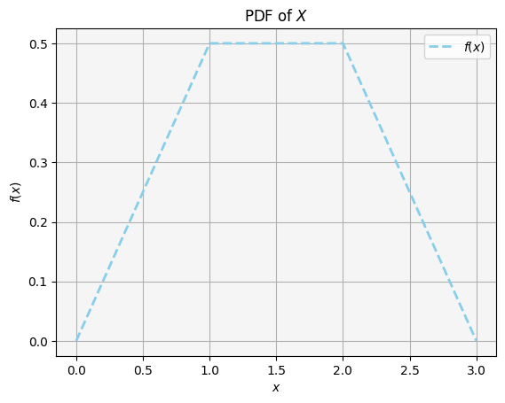

```python
# Define the piecewise function f(x)
def f(x):
    """
    Define the piecewise function f(x)
    """
    if 0 <= x <= 1:
        # linear function from 0 to 1
        return 0.5 * x
    elif 1 <= x <= 2:
        # constant function from 1 to 2
        return 0.5
    elif 2 <= x <= 3:
        # linear function from 2 to 3
        return 1.5 - 0.5 * x
    else:
        # return 0 for x outside the range [0, 3]
        return 0

# Generate x values from 0 to 3 with 1000 points
x_values = np.linspace(0, 3, 1000)

# Evaluate the function f(x) at each x value
y_values = np.array([f(x) for x in x_values])

# Create a plot of the function
plt.plot(x_values, y_values, label='$f(x)$', color='skyblue', linewidth=2, linestyle='--')
plt.xlabel('$x$')  # label the x-axis
plt.ylabel('$f(x)$')  # label the y-axis
plt.title('PDF of $X$')  # title of the plot
plt.legend()  # add a legend
plt.grid(True)  # add a grid
plt.gca().set_facecolor('whitesmoke')  # set the background color of the plot
plt.show()  # display the plot
```

#### (ii) Determine $P(X \leq 1.5)$

$$ P(X \leq 1.5) = \int_{0}^{1.5} f(x) \, dx $$

This integral can be broken down into two parts:

$$ P(X \leq 1.5) = \int_{0}^{1} 0.5x \, dx + \int_{1}^{1.5} 0.5 \, dx $$

Solving these integrals:

$$ \frac{0.5}{2} x^2 \bigg|_{0}^{1} + 0.5x \bigg|_{1}^{1.5} = \frac{1}{4} + 0.5(0.5) = 0.25 + 0.25 = 0.5 $$

So, $P(X \leq 1.5) = 0.5$.

#### (iii) Find $F(x)$ (Cumulative Distribution Function)

The cumulative distribution function $F(x)$ is given by:

$$ F(x) = \int_{-\infty}^{x} f(t) \, dt $$

For different intervals of $x$:

For $0 \leq x \leq 1$:

$$ F(x) = \int_{0}^{x} 0.5t \, dt = \frac{0.5}{2} x^2 = \frac{x^2}{4} $$

For $1 \leq x \leq 2$:

$$ F(x) = \int_{0}^{1} 0.5t \, dt + \int_{1}^{x} 0.5 \, dt = \frac{1}{4} + 0.5(x - 1) = \frac{1}{4} + 0.5x - 0.5 = 0.5x - 0.25 $$

For $2 \leq x \leq 3$:

$$ F(x) = \int_{0}^{1} 0.5t \, dt + \int_{1}^{2} 0.5 \, dt + \int_{2}^{x} (1.5 - 0.5t) \, dt $$

Solving the integrals:

$$ F(x) = \frac{1}{4} + 0.5(1) + [1.5x - \frac{0.5}{2} x^2 - (3 - 2)] $$

$$ F(x) = \frac{1}{4} + 0.5 + 1.5x - \frac{x^2}{4} - 1 = 1.5x - \frac{x^2}{4} - 0.25 $$

For $x > 3$:

$$ F(x) = 1 $$

So, the cumulative distribution function is:

$$ F(x) = \begin{cases} 0 & \text{for } x < 0 \\ \frac{x^2}{4} & \text{for } 0 \leq x \leq 1 \\ 0.5x - 0.25 & \text{for } 1 \leq x \leq 2 \\ 1.5x - \frac{x^2}{4} - 0.25 & \text{for } 2 \leq x \leq 3 \\ 1 & \text{for } x > 3 \end{cases} $$

#### (iv) Determine the expectation and variance of $X$

The expectation $E(X)$ is given by:

$$ E(X) = \int_{0}^{3} x f(x) \, dx $$

Breaking it down:

$$ E(X) = \int_{0}^{1} x \cdot 0.5x \, dx + \int_{1}^{2} x \cdot 0.5 \, dx + \int_{2}^{3} x (1.5 - 0.5x) \, dx $$

Solving these integrals:

$$ E(X) = 0.5 \int_{0}^{1} x^2 \, dx + 0.5 \int_{1}^{2} x \, dx + \int_{2}^{3} (1.5x - 0.5x^2) \, dx $$

$$ = 0.5 \cdot \frac{x^3}{3} \bigg|_{0}^{1} + 0.5 \cdot \frac{x^2}{2} \bigg|_{1}^{2} + \left[ 1.5 \cdot \frac{x^2}{2} - \frac{0.5x^3}{3} \right] \bigg|_{2}^{3} $$

$$ = 0.5 \cdot \frac{1}{3} + 0.5 \left( \frac{4}{2} - \frac{1}{2} \right) + \left( 1.5 \cdot \frac{9}{2} - \frac{0.5 \cdot 27}{3} - (1.5 \cdot 2 - \frac{0.5 \cdot 8}{3}) \right) $$

$$ = \frac{1}{6} + 0.5 \cdot 1.5 + \left( 6.75 - 4.5 - (3 - \frac{4}{3}) \right) $$

$$ = \frac{1}{6} + 0.75 + \left( 6.75 - 4.5 - 3 + \frac{4}{3} \right) $$

$$ = \frac{1}{6} + 0.75 + (2.25 - 3 + \frac{4}{3}) = \frac{1}{6} + 0.75 + (-0.75 + \frac{4}{3}) $$

$$ = \frac{1}{6} + 0.75 + \frac{4}{3} - 0.75 = \frac{1}{6} + \frac{4}{3} $$

$$ = \frac{1 + 8}{6} = \frac{9}{6} = 1.5 $$

So, $E(X) = 1.5$.

For the variance $Var(X)$:

$$ Var(X) = E(X^2) - (E(X))^2 $$

We already have $E(X) = 1.5$, so we need $E(X^2)$:

$$ E(X^2) = \int_{0}^{3} x^2 f(x) \, dx $$

Breaking it down:

$$ E(X^2) = \int_{0}^{1} x^2 \cdot 0.5x \, dx + \int_{1}^{2} x^2 \cdot 0.5 \, dx + \int_{2}^{3} x^2 (1.5 - 0.5x) \, dx $$

Solving these integrals:

$$ E(X^2) = 0.5 \int_{0}^{1} x^3 \, dx + 0.5 \int_{1}^{2} x^2 \, dx + \int_{2}^{3} (1.5x^2 - 0.5x^3) \, dx $$

$$ = 0.5 \cdot \frac{x^4}{4} \bigg|_{0}^{1} + 0.5 \cdot \frac{x^3}{3} \bigg|_{1}^{2} + \left[ 1.5 \cdot \frac{x^3}{3} - 0.5 \cdot \frac{x^4}{4} \right] \bigg|_{2}^{3} $$

$$ = 0.5 \cdot \frac{1}{4} + 0.5 \left( \frac{8}{3} - \frac{1}{3} \right) + \left( 1.5 \cdot \frac{27}{3} - 0.5 \cdot \frac{81}{4} - (1.5 \cdot \frac{8}{3} - 0.5 \cdot \frac{16}{4}) \right) $$

$$ = \frac{1}{8} + 0.5 \cdot \frac{7}{3} + \left( 13.5 - 10.125 - (4 - 2) \right) $$

$$ = \frac{1}{8} + \frac{7}{6} + \left( 13.5 - 10.125 - 2 \right) $$

$$ = \frac{1}{8} + \frac{7}{6} + 1.375 $$

Finding a common denominator for the fractions:

$$ = \frac{3}{24} + \frac{28}{24} + \frac{33}{24} $$

$$ = \frac{64}{24} = \frac{8}{3} $$

So, $E(X^2) = \frac{8}{3}$.

Now, $Var(X)$:

$$ Var(X) = \frac{8}{3} - (1.5)^2 = \frac{8}{3} - \frac{9}{4} $$

Finding a common denominator for the fractions:

$$ = \frac{32}{12} - \frac{27}{12} = \frac{5}{12} $$

So, $Var(X) = \frac{5}{12}$.

Thus, the expectation and variance of $X$ are $1.5$ and $\frac{5}{12}$, respectively.

### Question 5(b):

**Let $X_1, ..., X_{10}$ be a random sample from a population with mean 50 and standard deviation 4. Let $\bar{X}$ be the sample mean. Find the expected value and standard deviation of $\bar{X}$.**

**Solution:**

Given:

- Assuming that $ X_1, X_2, \ldots, X_{10} $ are independent and identically distributed random variables from a population with mean $ \mu = 50 $ and standard deviation $ \sigma = 4 $.
- Sample size $ n = 10 $.
- $ \bar{X} $ is the sample mean.

### Expected Value of $ \bar{X} $:

The expected value of the sample mean $ \bar{X} $ is equal to the population mean $ \mu $. $$ E[\bar{X}] = \mu = 50 $$

### Standard Deviation of $ \bar{X} $:

The standard deviation of the sample mean $ \bar{X} $ is given by: $$ \text{SD}(\bar{X}) = \frac{\sigma}{\sqrt{n}} $$ where $ \sigma $ is the population standard deviation and $ n $ is the sample size.

Substitute $ \sigma = 4 $ and $ n = 10 $: $$ \text{SD}(\bar{X}) = \frac{4}{\sqrt{10}} $$

Calculating this gives: $$ \text{SD}(\bar{X}) = \frac{4}{\sqrt{10}} \approx 1.2649 $$

Therefore, the expected value of $ \bar{X} $ is $ 50 $ and the standard deviation of $ \bar{X} $ is approximately $ 1.2649 $.

### Question 5(c):

**A wireless communication company is offering a flat-fee plan to 1000 customers for one month. The standard deviation of monthly minutes is about 120 minutes. Find the probability that the average among the 1000 test customers will differ from the true mean by more than 5 minutes.**

**Solution:**

To find the probability that the sample mean among 1000 customers differs from the true mean by more than 5 minutes, we'll use the Central Limit Theorem (CLT). Here are the steps to solve this:

Given:

- Population standard deviation ($ \sigma $) of monthly minutes = 120 minutes.
- Sample size ($ n $) = 1000.

### Step 1: Calculate the Standard Error of the Mean

The standard error of the mean ($ SE $) is given by: $$ SE = \frac{\sigma}{\sqrt{n}} $$

Substitute $ \sigma = 120 $ minutes and $ n = 1000 $: $$ SE = \frac{120}{\sqrt{1000}} $$ $$ SE = \frac{120}{31.62} $$ $$ SE \approx 3.79 $$

### Step 2: Determine the Probability using the Normal Distribution

The probability that the sample mean differs from the true mean by more than 5 minutes can be approximated using the normal distribution, due to the CLT.

Let $ \bar{X} $ be the sample mean. We are interested in finding $ P(|\bar{X} - \mu| > 5) $.

$$ P(|\bar{X} - \mu| > 5) = P\left(\left|\frac{\bar{X} - \mu}{SE}\right| > \frac{5}{SE}\right) $$ $$ = P\left(\left|\frac{\bar{X} - \mu}{3.79}\right| > \frac{5}{3.79}\right) $$ $$ \approx P\left(\left|\frac{\bar{X} - \mu}{3.79}\right| > 1.32\right) $$

### Step 3: Calculate the Z-score and Find the Probability

```python
import math
from scipy import stats

# Given data
sigma = 120  # Standard deviation of monthly minutes
n = 1000     # Sample size

# Calculate the standard error of the mean
SE = sigma / (n ** 0.5)

# Margin of error in minutes
margin_of_error = 5

# Calculate the Z-score
z_score = margin_of_error / SE

# Calculate the probability using the complementary CDF
probability = 1 - stats.norm.cdf(z_score)

# Print the results
print(f"Z-score: {z_score:.4f}")
print(f"Probability that |X̄ - μ| > 5 minutes: {probability:.4f}")
```

```
Z-score: 1.3176
Probability that |X̄ - μ| > 5 minutes: 0.0938
```

### Question 5(d):

**A company believes that roughly 35% of consumers rate its brand first in quality. It wants to estimate the proportion more accurately with a survey. Determine how large the sample size $n$ must be to ensure that there is only a 5% chance that the estimate from the survey will differ from the true value by more than 3 percentage points.**

**My Solution:**

To determine the required sample size, we can use the formula derived from the normal approximation to the binomial distribution.

Given Values:

- Desired margin of error (E) = 3 percentage points = 0.03
- Desired confidence level = 95%, corresponding to a significance level of α = 0.05
- Estimated proportion (p̂) from pilot studies or initial estimates = 0.35 (35%)

### Formula for Sample Size $ n $:

The formula for calculating the sample size n is:

$$n = \frac{Z^2 \cdot \hat{p} \cdot (1 - \hat{p})}{E^2}$$

Where:

- Z is the Z-score corresponding to the desired confidence level (1 - α)
- p̂ is the estimated proportion
- E is the margin of error

### Step-by-Step Calculation:

1. **Find the Z-score**: For a 95% confidence level, Z is approximately 1.96 (using standard normal distribution tables).
2. **Substitute the values** into the formula:

$$n = \frac{(1.96)^2 \cdot 0.35 \cdot (1 - 0.35)}{(0.03)^2}$$

3. **Calculate $ n $**: $$ n = \frac{3.8416 \cdot 0.35 \cdot 0.65}{0.0009} $$ $$ n = \frac{0.873964}{0.0009} $$ $$ n \approx 971.07$$
4. **Round up to the nearest whole number**: Since $ n $ must be a whole number, round up $ 971.07 $ to $ 971 $.

### Final thoughts and Conclusion:

Final Thoughts and Conclusion In conclusion, to achieve a 95% confidence level with a margin of error of 3 percentage points around the estimated proportion of 35%, the sample size must be at least $ 971 $. This ensures that there is only a 5% chance that the survey's estimate will differ from the true proportion by more than 3 percentage points.